# Risk Factor Analysis

## Outcome Variable

**Outcome Variable:** wasted

## Predictor Variables

**Intervention Variable:** impfloor

**Adjustment Set:**

unadjusted

## Stratifying Variables

The analysis was stratified on these variable(s):

- agecat
- studyid
- country

## Data Summary

| agecat | studyid | country | impfloor | wasted | n_cell | n |
| --- | --- | --- | --- | --- | --- | --- |
| Birth | ki0047075b-MAL-ED | BANGLADESH | 1 | 0 | 150 | 201 |
| Birth | ki0047075b-MAL-ED | BANGLADESH | 1 | 1 | 35 | 201 |
| Birth | ki0047075b-MAL-ED | BANGLADESH | 0 | 0 | 16 | 201 |
| Birth | ki0047075b-MAL-ED | BANGLADESH | 0 | 1 | 0 | 201 |
| Birth | ki0047075b-MAL-ED | BRAZIL | 1 | 0 | 53 | 57 |
| Birth | ki0047075b-MAL-ED | BRAZIL | 1 | 1 | 2 | 57 |
| Birth | ki0047075b-MAL-ED | BRAZIL | 0 | 0 | 2 | 57 |
| Birth | ki0047075b-MAL-ED | BRAZIL | 0 | 1 | 0 | 57 |
| Birth | ki0047075b-MAL-ED | INDIA | 1 | 0 | 29 | 39 |
| Birth | ki0047075b-MAL-ED | INDIA | 1 | 1 | 4 | 39 |
| Birth | ki0047075b-MAL-ED | INDIA | 0 | 0 | 5 | 39 |
| Birth | ki0047075b-MAL-ED | INDIA | 0 | 1 | 1 | 39 |
| Birth | ki0047075b-MAL-ED | NEPAL | 1 | 0 | 7 | 24 |
| Birth | ki0047075b-MAL-ED | NEPAL | 1 | 1 | 1 | 24 |
| Birth | ki0047075b-MAL-ED | NEPAL | 0 | 0 | 15 | 24 |
| Birth | ki0047075b-MAL-ED | NEPAL | 0 | 1 | 1 | 24 |
| Birth | ki0047075b-MAL-ED | PERU | 1 | 0 | 36 | 210 |
| Birth | ki0047075b-MAL-ED | PERU | 1 | 1 | 1 | 210 |
| Birth | ki0047075b-MAL-ED | PERU | 0 | 0 | 169 | 210 |
| Birth | ki0047075b-MAL-ED | PERU | 0 | 1 | 4 | 210 |
| Birth | ki0047075b-MAL-ED | SOUTH AFRICA | 1 | 0 | 76 | 95 |
| Birth | ki0047075b-MAL-ED | SOUTH AFRICA | 1 | 1 | 10 | 95 |
| Birth | ki0047075b-MAL-ED | SOUTH AFRICA | 0 | 0 | 9 | 95 |
| Birth | ki0047075b-MAL-ED | SOUTH AFRICA | 0 | 1 | 0 | 95 |
| Birth | ki0047075b-MAL-ED | TANZANIA, UNITED REPUBLIC OF | 1 | 0 | 5 | 111 |
| Birth | ki0047075b-MAL-ED | TANZANIA, UNITED REPUBLIC OF | 1 | 1 | 0 | 111 |
| Birth | ki0047075b-MAL-ED | TANZANIA, UNITED REPUBLIC OF | 0 | 0 | 105 | 111 |
| Birth | ki0047075b-MAL-ED | TANZANIA, UNITED REPUBLIC OF | 0 | 1 | 1 | 111 |
| Birth | ki1000108-CMC-V-BCS-2002 | INDIA | 1 | 0 | 59 | 68 |
| Birth | ki1000108-CMC-V-BCS-2002 | INDIA | 1 | 1 | 9 | 68 |

[output cut: 162 more lines]

The following strata were considered:

- agecat: 24 months, studyid: ki0047075b-MAL-ED, country: BANGLADESH
- agecat: 24 months, studyid: ki0047075b-MAL-ED, country: BRAZIL
- agecat: 24 months, studyid: ki0047075b-MAL-ED, country: INDIA
- agecat: 24 months, studyid: ki0047075b-MAL-ED, country: NEPAL
- agecat: 24 months, studyid: ki0047075b-MAL-ED, country: PERU
- agecat: 24 months, studyid: ki0047075b-MAL-ED, country: SOUTH AFRICA
- agecat: 24 months, studyid: ki0047075b-MAL-ED, country: TANZANIA, UNITED REPUBLIC OF
- agecat: 24 months, studyid: ki1000108-CMC-V-BCS-2002, country: INDIA
- agecat: 24 months, studyid: ki1000108-IRC, country: INDIA
- agecat: 24 months, studyid: ki1017093-NIH-Birth, country: BANGLADESH
- agecat: 24 months, studyid: ki1017093b-PROVIDE, country: BANGLADESH
- agecat: 24 months, studyid: ki1017093c-NIH-Crypto, country: BANGLADESH
- agecat: 24 months, studyid: ki1113344-GMS-Nepal, country: NEPAL
- agecat: 24 months, studyid: ki1114097-CONTENT, country: PERU
- agecat: 24 months, studyid: kiGH5241-JiVitA-3, country: BANGLADESH
- agecat: 24 months, studyid: kiGH5241-JiVitA-4, country: BANGLADESH
- agecat: 6 months, studyid: ki0047075b-MAL-ED, country: BANGLADESH
- agecat: 6 months, studyid: ki0047075b-MAL-ED, country: BRAZIL
- agecat: 6 months, studyid: ki0047075b-MAL-ED, country: INDIA
- agecat: 6 months, studyid: ki0047075b-MAL-ED, country: NEPAL
- agecat: 6 months, studyid: ki0047075b-MAL-ED, country: PERU
- agecat: 6 months, studyid: ki0047075b-MAL-ED, country: SOUTH AFRICA
- agecat: 6 months, studyid: ki0047075b-MAL-ED, country: TANZANIA, UNITED REPUBLIC OF
- agecat: 6 months, studyid: ki1000108-CMC-V-BCS-2002, country: INDIA
- agecat: 6 months, studyid: ki1000108-IRC, country: INDIA
- agecat: 6 months, studyid: ki1017093-NIH-Birth, country: BANGLADESH
- agecat: 6 months, studyid: ki1017093b-PROVIDE, country: BANGLADESH
- agecat: 6 months, studyid: ki1017093c-NIH-Crypto, country: BANGLADESH
- agecat: 6 months, studyid: ki1113344-GMS-Nepal, country: NEPAL
- agecat: 6 months, studyid: ki1114097-CONTENT, country: PERU
- agecat: 6 months, studyid: kiGH5241-JiVitA-3, country: BANGLADESH
- agecat: 6 months, studyid: kiGH5241-JiVitA-4, country: BANGLADESH
- agecat: Birth, studyid: ki0047075b-MAL-ED, country: BANGLADESH
- agecat: Birth, studyid: ki0047075b-MAL-ED, country: BRAZIL
- agecat: Birth, studyid: ki0047075b-MAL-ED, country: INDIA
- agecat: Birth, studyid: ki0047075b-MAL-ED, country: NEPAL
- agecat: Birth, studyid: ki0047075b-MAL-ED, country: PERU
- agecat: Birth, studyid: ki0047075b-MAL-ED, country: SOUTH AFRICA
- agecat: Birth, studyid: ki0047075b-MAL-ED, country: TANZANIA, UNITED REPUBLIC OF
- agecat: Birth, studyid: ki1000108-CMC-V-BCS-2002, country: INDIA
- agecat: Birth, studyid: ki1000108-IRC, country: INDIA
- agecat: Birth, studyid: ki1017093-NIH-Birth, country: BANGLADESH
- agecat: Birth, studyid: ki1017093b-PROVIDE, country: BANGLADESH
- agecat: Birth, studyid: ki1017093c-NIH-Crypto, country: BANGLADESH
- agecat: Birth, studyid: ki1113344-GMS-Nepal, country: NEPAL
- agecat: Birth, studyid: ki1114097-CONTENT, country: PERU
- agecat: Birth, studyid: kiGH5241-JiVitA-3, country: BANGLADESH
- agecat: Birth, studyid: kiGH5241-JiVitA-4, country: BANGLADESH

### Dropped Strata

Some strata were dropped due to rare outcomes:

- agecat: Birth, studyid: ki0047075b-MAL-ED, country: BANGLADESH
- agecat: Birth, studyid: ki0047075b-MAL-ED, country: BRAZIL
- agecat: Birth, studyid: ki0047075b-MAL-ED, country: INDIA
- agecat: Birth, studyid: ki0047075b-MAL-ED, country: NEPAL
- agecat: Birth, studyid: ki0047075b-MAL-ED, country: PERU
- agecat: Birth, studyid: ki0047075b-MAL-ED, country: SOUTH AFRICA
- agecat: Birth, studyid: ki0047075b-MAL-ED, country: TANZANIA, UNITED REPUBLIC OF
- agecat: Birth, studyid: ki1000108-CMC-V-BCS-2002, country: INDIA
- agecat: Birth, studyid: ki1000108-IRC, country: INDIA
- agecat: Birth, studyid: ki1114097-CONTENT, country: PERU
- agecat: 6 months, studyid: ki0047075b-MAL-ED, country: BANGLADESH
- agecat: 6 months, studyid: ki0047075b-MAL-ED, country: BRAZIL
- agecat: 6 months, studyid: ki0047075b-MAL-ED, country: INDIA
- agecat: 6 months, studyid: ki0047075b-MAL-ED, country: NEPAL
- agecat: 6 months, studyid: ki0047075b-MAL-ED, country: PERU
- agecat: 6 months, studyid: ki0047075b-MAL-ED, country: SOUTH AFRICA
- agecat: 6 months, studyid: ki0047075b-MAL-ED, country: TANZANIA, UNITED REPUBLIC OF
- agecat: 6 months, studyid: ki1000108-CMC-V-BCS-2002, country: INDIA
- agecat: 6 months, studyid: ki1000108-IRC, country: INDIA
- agecat: 6 months, studyid: ki1017093b-PROVIDE, country: BANGLADESH
- agecat: 6 months, studyid: ki1114097-CONTENT, country: PERU
- agecat: 24 months, studyid: ki0047075b-MAL-ED, country: BANGLADESH
- agecat: 24 months, studyid: ki0047075b-MAL-ED, country: BRAZIL
- agecat: 24 months, studyid: ki0047075b-MAL-ED, country: INDIA
- agecat: 24 months, studyid: ki0047075b-MAL-ED, country: NEPAL
- agecat: 24 months, studyid: ki0047075b-MAL-ED, country: PERU
- agecat: 24 months, studyid: ki0047075b-MAL-ED, country: SOUTH AFRICA
- agecat: 24 months, studyid: ki0047075b-MAL-ED, country: TANZANIA, UNITED REPUBLIC OF
- agecat: 24 months, studyid: ki1000108-CMC-V-BCS-2002, country: INDIA
- agecat: 24 months, studyid: ki1000108-IRC, country: INDIA
- agecat: 24 months, studyid: ki1114097-CONTENT, country: PERU

## Methods Detail

We’re interested in the causal parameters $E[Y_a]$ for all values of $a \in \mathcal{A}$. These parameters represent the mean outcome if, possibly contrary to fact, we intervened to set all units to have $A=a$. Under the randomization and positivity assumptions, these are identified by the statistical parameters $\psi_a=E_W[E_{Y|A,W}(Y|A=a,W)]$. In addition, we’re interested in the mean of $Y$, $E[Y]$ under no intervention (the observed mean). We will estimate these parameters by using SuperLearner to fit the relevant likelihood factors – $E_{Y|A,W}(Y|A=a,W)$ and $p(A=a|W)$, and then updating our likelihood fit using a joint TMLE.

For unadjusted analyses ($W=\{\}$), initial likelihoods were estimated using Lrnr_glm to estimate the simple $E(Y|A)$ and Lrnr_mean to estimate $p(A)$. For adjusted analyses, a small library containing Lrnr_glmnet, Lrnr_xgboost, and Lrnr_mean was used.

Having estimated these parameters, we will then use the delta method to estimate relative risks and attributable risks relative to a prespecified baseline level of $A$.

# Results Detail

## Results Plots

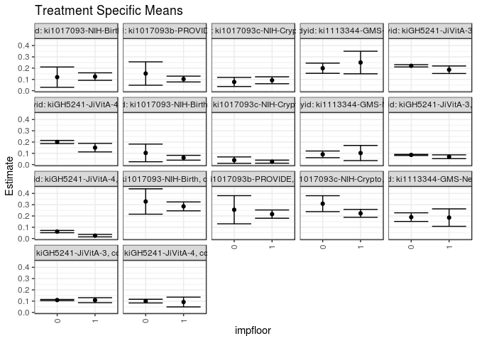

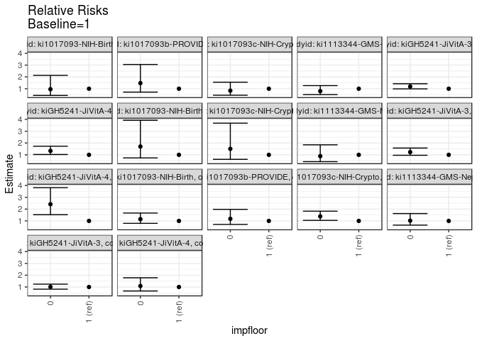

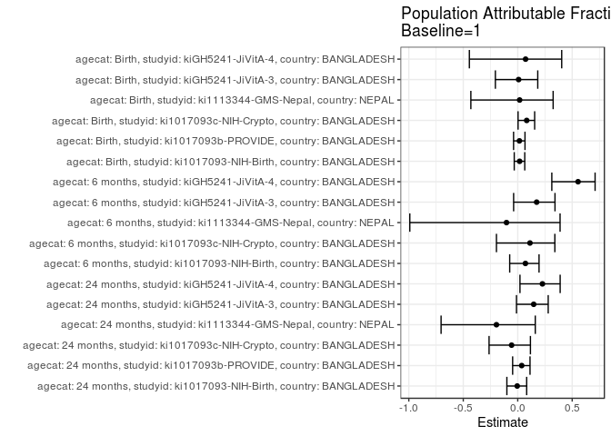

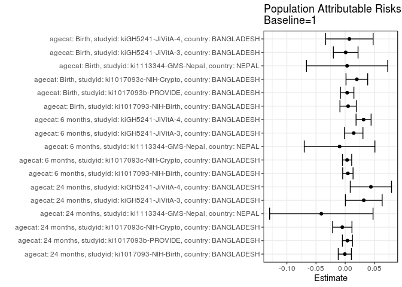

## Results Table

### Parameter: TSM

| agecat | studyid | country | intervention_level | baseline_level | estimate | ci_lower | ci_upper |
| --- | --- | --- | --- | --- | --- | --- | --- |
| Birth | ki1017093-NIH-Birth | BANGLADESH | 1 | NA | 0.2851485 | 0.2457368 | 0.3245603 |
| Birth | ki1017093-NIH-Birth | BANGLADESH | 0 | NA | 0.3283582 | 0.2158113 | 0.4409051 |
| Birth | ki1017093b-PROVIDE | BANGLADESH | 1 | NA | 0.2164948 | 0.1798063 | 0.2531834 |
| Birth | ki1017093b-PROVIDE | BANGLADESH | 0 | NA | 0.2553191 | 0.1305422 | 0.3800961 |
| Birth | ki1017093c-NIH-Crypto | BANGLADESH | 1 | NA | 0.2232472 | 0.1881648 | 0.2583297 |
| Birth | ki1017093c-NIH-Crypto | BANGLADESH | 0 | NA | 0.3090909 | 0.2385295 | 0.3796523 |
| Birth | ki1113344-GMS-Nepal | NEPAL | 1 | NA | 0.1855670 | 0.1081257 | 0.2630083 |
| Birth | ki1113344-GMS-Nepal | NEPAL | 0 | NA | 0.1896552 | 0.1514841 | 0.2278263 |
| Birth | kiGH5241-JiVitA-3 | BANGLADESH | 1 | NA | 0.1086420 | 0.0866167 | 0.1306673 |
| Birth | kiGH5241-JiVitA-3 | BANGLADESH | 0 | NA | 0.1096054 | 0.1043290 | 0.1148818 |
| Birth | kiGH5241-JiVitA-4 | BANGLADESH | 1 | NA | 0.0922509 | 0.0488665 | 0.1356353 |
| Birth | kiGH5241-JiVitA-4 | BANGLADESH | 0 | NA | 0.1003297 | 0.0840328 | 0.1166266 |
| 6 months | ki1017093-NIH-Birth | BANGLADESH | 1 | NA | 0.0607966 | 0.0393324 | 0.0822608 |
| 6 months | ki1017093-NIH-Birth | BANGLADESH | 0 | NA | 0.1034483 | 0.0249989 | 0.1818977 |
| 6 months | ki1017093c-NIH-Crypto | BANGLADESH | 1 | NA | 0.0260708 | 0.0125841 | 0.0395575 |
| 6 months | ki1017093c-NIH-Crypto | BANGLADESH | 0 | NA | 0.0393258 | 0.0107520 | 0.0678997 |
| 6 months | ki1113344-GMS-Nepal | NEPAL | 1 | NA | 0.1025641 | 0.0351589 | 0.1699693 |
| 6 months | ki1113344-GMS-Nepal | NEPAL | 0 | NA | 0.0909091 | 0.0613020 | 0.1205161 |
| 6 months | kiGH5241-JiVitA-3 | BANGLADESH | 1 | NA | 0.0697198 | 0.0529533 | 0.0864862 |
| 6 months | kiGH5241-JiVitA-3 | BANGLADESH | 0 | NA | 0.0857816 | 0.0808136 | 0.0907496 |
| 6 months | kiGH5241-JiVitA-4 | BANGLADESH | 1 | NA | 0.0254237 | 0.0145373 | 0.0363101 |
| 6 months | kiGH5241-JiVitA-4 | BANGLADESH | 0 | NA | 0.0613787 | 0.0514581 | 0.0712992 |
| 24 months | ki1017093-NIH-Birth | BANGLADESH | 1 | NA | 0.1250000 | 0.0915325 | 0.1584675 |
| 24 months | ki1017093-NIH-Birth | BANGLADESH | 0 | NA | 0.1200000 | 0.0298210 | 0.2101790 |
| 24 months | ki1017093b-PROVIDE | BANGLADESH | 1 | NA | 0.1031895 | 0.0773414 | 0.1290376 |
| 24 months | ki1017093b-PROVIDE | BANGLADESH | 0 | NA | 0.1521739 | 0.0482853 | 0.2560625 |
| 24 months | ki1017093c-NIH-Crypto | BANGLADESH | 1 | NA | 0.0924855 | 0.0619295 | 0.1230416 |
| 24 months | ki1017093c-NIH-Crypto | BANGLADESH | 0 | NA | 0.0773810 | 0.0369378 | 0.1178241 |
| 24 months | ki1113344-GMS-Nepal | NEPAL | 1 | NA | 0.2500000 | 0.1498467 | 0.3501533 |
| 24 months | ki1113344-GMS-Nepal | NEPAL | 0 | NA | 0.1993355 | 0.1541431 | 0.2445280 |
| 24 months | kiGH5241-JiVitA-3 | BANGLADESH | 1 | NA | 0.1860119 | 0.1527268 | 0.2192970 |
| 24 months | kiGH5241-JiVitA-3 | BANGLADESH | 0 | NA | 0.2206626 | 0.2105217 | 0.2308035 |
| 24 months | kiGH5241-JiVitA-4 | BANGLADESH | 1 | NA | 0.1504425 | 0.1126099 | 0.1882750 |
| 24 months | kiGH5241-JiVitA-4 | BANGLADESH | 0 | NA | 0.2005283 | 0.1865356 | 0.2145211 |

### Parameter: E(Y)

| agecat | studyid | country | intervention_level | baseline_level | estimate | ci_lower | ci_upper |
| --- | --- | --- | --- | --- | --- | --- | --- |
| Birth | ki1017093-NIH-Birth | BANGLADESH | NA | NA | 0.2902098 | 0.2529834 | 0.3274362 |
| Birth | ki1017093b-PROVIDE | BANGLADESH | NA | NA | 0.2199248 | 0.1846953 | 0.2551543 |
| Birth | ki1017093c-NIH-Crypto | BANGLADESH | NA | NA | 0.2432815 | 0.2116319 | 0.2749310 |
| Birth | ki1113344-GMS-Nepal | NEPAL | NA | NA | 0.1888668 | 0.1546279 | 0.2231057 |
| Birth | kiGH5241-JiVitA-3 | BANGLADESH | NA | NA | 0.1095402 | 0.1044185 | 0.1146620 |
| Birth | kiGH5241-JiVitA-4 | BANGLADESH | NA | NA | 0.0994152 | 0.0840401 | 0.1147903 |
| 6 months | ki1017093-NIH-Birth | BANGLADESH | NA | NA | 0.0654206 | 0.0444484 | 0.0863927 |
| 6 months | ki1017093c-NIH-Crypto | BANGLADESH | NA | NA | 0.0293706 | 0.0169860 | 0.0417552 |
| 6 months | ki1113344-GMS-Nepal | NEPAL | NA | NA | 0.0929705 | 0.0658371 | 0.1201040 |
| 6 months | kiGH5241-JiVitA-3 | BANGLADESH | NA | NA | 0.0843784 | 0.0795716 | 0.0891851 |
| 6 months | kiGH5241-JiVitA-4 | BANGLADESH | NA | NA | 0.0569830 | 0.0481380 | 0.0658280 |
| 24 months | ki1017093-NIH-Birth | BANGLADESH | NA | NA | 0.1244131 | 0.0930343 | 0.1557919 |
| 24 months | ki1017093b-PROVIDE | BANGLADESH | NA | NA | 0.1070812 | 0.0818727 | 0.1322897 |
| 24 months | ki1017093c-NIH-Crypto | BANGLADESH | NA | NA | 0.0875486 | 0.0630907 | 0.1120065 |
| 24 months | ki1113344-GMS-Nepal | NEPAL | NA | NA | 0.2091153 | 0.1677890 | 0.2504415 |
| 24 months | kiGH5241-JiVitA-3 | BANGLADESH | NA | NA | 0.2179487 | 0.2080959 | 0.2278016 |
| 24 months | kiGH5241-JiVitA-4 | BANGLADESH | NA | NA | 0.1945443 | 0.1813282 | 0.2077604 |

### Parameter: RR

| agecat | studyid | country | intervention_level | baseline_level | estimate | ci_lower | ci_upper |
| --- | --- | --- | --- | --- | --- | --- | --- |
| Birth | ki1017093-NIH-Birth | BANGLADESH | 1 | 1 | 1.0000000 | 1.0000000 | 1.000000 |
| Birth | ki1017093-NIH-Birth | BANGLADESH | 0 | 1 | 1.1515340 | 0.7957426 | 1.666406 |
| Birth | ki1017093b-PROVIDE | BANGLADESH | 1 | 1 | 1.0000000 | 1.0000000 | 1.000000 |
| Birth | ki1017093b-PROVIDE | BANGLADESH | 0 | 1 | 1.1793313 | 0.7030617 | 1.978237 |
| Birth | ki1017093c-NIH-Crypto | BANGLADESH | 1 | 1 | 1.0000000 | 1.0000000 | 1.000000 |
| Birth | ki1017093c-NIH-Crypto | BANGLADESH | 0 | 1 | 1.3845229 | 1.0493907 | 1.826682 |
| Birth | ki1113344-GMS-Nepal | NEPAL | 1 | 1 | 1.0000000 | 1.0000000 | 1.000000 |
| Birth | ki1113344-GMS-Nepal | NEPAL | 0 | 1 | 1.0220307 | 0.6430525 | 1.624357 |
| Birth | kiGH5241-JiVitA-3 | BANGLADESH | 1 | 1 | 1.0000000 | 1.0000000 | 1.000000 |
| Birth | kiGH5241-JiVitA-3 | BANGLADESH | 0 | 1 | 1.0088679 | 0.8186237 | 1.243324 |
| Birth | kiGH5241-JiVitA-4 | BANGLADESH | 1 | 1 | 1.0000000 | 1.0000000 | 1.000000 |
| Birth | kiGH5241-JiVitA-4 | BANGLADESH | 0 | 1 | 1.0875741 | 0.6634906 | 1.782719 |
| 6 months | ki1017093-NIH-Birth | BANGLADESH | 1 | 1 | 1.0000000 | 1.0000000 | 1.000000 |
| 6 months | ki1017093-NIH-Birth | BANGLADESH | 0 | 1 | 1.7015458 | 0.7371519 | 3.927628 |
| 6 months | ki1017093c-NIH-Crypto | BANGLADESH | 1 | 1 | 1.0000000 | 1.0000000 | 1.000000 |
| 6 months | ki1017093c-NIH-Crypto | BANGLADESH | 0 | 1 | 1.5084270 | 0.6182469 | 3.680329 |
| 6 months | ki1113344-GMS-Nepal | NEPAL | 1 | 1 | 1.0000000 | 1.0000000 | 1.000000 |
| 6 months | ki1113344-GMS-Nepal | NEPAL | 0 | 1 | 0.8863636 | 0.4256670 | 1.845669 |
| 6 months | kiGH5241-JiVitA-3 | BANGLADESH | 1 | 1 | 1.0000000 | 1.0000000 | 1.000000 |
| 6 months | kiGH5241-JiVitA-3 | BANGLADESH | 0 | 1 | 1.2303771 | 0.9625980 | 1.572648 |
| 6 months | kiGH5241-JiVitA-4 | BANGLADESH | 1 | 1 | 1.0000000 | 1.0000000 | 1.000000 |
| 6 months | kiGH5241-JiVitA-4 | BANGLADESH | 0 | 1 | 2.4142273 | 1.5276742 | 3.815272 |
| 24 months | ki1017093-NIH-Birth | BANGLADESH | 1 | 1 | 1.0000000 | 1.0000000 | 1.000000 |
| 24 months | ki1017093-NIH-Birth | BANGLADESH | 0 | 1 | 0.9600000 | 0.4323222 | 2.131743 |
| 24 months | ki1017093b-PROVIDE | BANGLADESH | 1 | 1 | 1.0000000 | 1.0000000 | 1.000000 |
| 24 months | ki1017093b-PROVIDE | BANGLADESH | 0 | 1 | 1.4747035 | 0.7126652 | 3.051574 |
| 24 months | ki1017093c-NIH-Crypto | BANGLADESH | 1 | 1 | 1.0000000 | 1.0000000 | 1.000000 |
| 24 months | ki1017093c-NIH-Crypto | BANGLADESH | 0 | 1 | 0.8366815 | 0.4508456 | 1.552718 |
| 24 months | ki1113344-GMS-Nepal | NEPAL | 1 | 1 | 1.0000000 | 1.0000000 | 1.000000 |
| 24 months | ki1113344-GMS-Nepal | NEPAL | 0 | 1 | 0.7973422 | 0.5031900 | 1.263448 |
| 24 months | kiGH5241-JiVitA-3 | BANGLADESH | 1 | 1 | 1.0000000 | 1.0000000 | 1.000000 |
| 24 months | kiGH5241-JiVitA-3 | BANGLADESH | 0 | 1 | 1.1862822 | 0.9889000 | 1.423062 |
| 24 months | kiGH5241-JiVitA-4 | BANGLADESH | 1 | 1 | 1.0000000 | 1.0000000 | 1.000000 |
| 24 months | kiGH5241-JiVitA-4 | BANGLADESH | 0 | 1 | 1.3329237 | 1.0275889 | 1.728985 |

### Parameter: PAR

| agecat | studyid | country | intervention_level | baseline_level | estimate | ci_lower | ci_upper |
| --- | --- | --- | --- | --- | --- | --- | --- |
| Birth | ki1017093-NIH-Birth | BANGLADESH | 1 | NA | 0.0050613 | -0.0089530 | 0.0190756 |
| Birth | ki1017093b-PROVIDE | BANGLADESH | 1 | NA | 0.0034300 | -0.0080984 | 0.0149583 |
| Birth | ki1017093c-NIH-Crypto | BANGLADESH | 1 | NA | 0.0200342 | 0.0014495 | 0.0386190 |
| Birth | ki1113344-GMS-Nepal | NEPAL | 1 | NA | 0.0032998 | -0.0663884 | 0.0729879 |
| Birth | kiGH5241-JiVitA-3 | BANGLADESH | 1 | NA | 0.0008983 | -0.0202786 | 0.0220752 |
| Birth | kiGH5241-JiVitA-4 | BANGLADESH | 1 | NA | 0.0071643 | -0.0336330 | 0.0479615 |
| 6 months | ki1017093-NIH-Birth | BANGLADESH | 1 | NA | 0.0046239 | -0.0042649 | 0.0135127 |
| 6 months | ki1017093c-NIH-Crypto | BANGLADESH | 1 | NA | 0.0032999 | -0.0045774 | 0.0111771 |
| 6 months | ki1113344-GMS-Nepal | NEPAL | 1 | NA | -0.0095936 | -0.0701945 | 0.0510073 |
| 6 months | kiGH5241-JiVitA-3 | BANGLADESH | 1 | NA | 0.0146586 | -0.0011622 | 0.0304794 |
| 6 months | kiGH5241-JiVitA-4 | BANGLADESH | 1 | NA | 0.0315593 | 0.0186653 | 0.0444532 |
| 24 months | ki1017093-NIH-Birth | BANGLADESH | 1 | NA | -0.0005869 | -0.0118777 | 0.0107040 |
| 24 months | ki1017093b-PROVIDE | BANGLADESH | 1 | NA | 0.0038917 | -0.0046819 | 0.0124653 |
| 24 months | ki1017093c-NIH-Crypto | BANGLADESH | 1 | NA | -0.0049369 | -0.0215157 | 0.0116418 |
| 24 months | ki1113344-GMS-Nepal | NEPAL | 1 | NA | -0.0408847 | -0.1295758 | 0.0478064 |
| 24 months | kiGH5241-JiVitA-3 | BANGLADESH | 1 | NA | 0.0319368 | 0.0004311 | 0.0634426 |
| 24 months | kiGH5241-JiVitA-4 | BANGLADESH | 1 | NA | 0.0441018 | 0.0086833 | 0.0795204 |

### Parameter: PAF

| agecat | studyid | country | intervention_level | baseline_level | estimate | ci_lower | ci_upper |
| --- | --- | --- | --- | --- | --- | --- | --- |
| Birth | ki1017093-NIH-Birth | BANGLADESH | 1 | NA | 0.0174401 | -0.0320458 | 0.0645531 |
| Birth | ki1017093b-PROVIDE | BANGLADESH | 1 | NA | 0.0155961 | -0.0382162 | 0.0666192 |
| Birth | ki1017093c-NIH-Crypto | BANGLADESH | 1 | NA | 0.0823500 | 0.0030235 | 0.1553648 |
| Birth | ki1113344-GMS-Nepal | NEPAL | 1 | NA | 0.0174715 | -0.4303343 | 0.3250793 |
| Birth | kiGH5241-JiVitA-3 | BANGLADESH | 1 | NA | 0.0082003 | -0.2052761 | 0.1838662 |
| Birth | kiGH5241-JiVitA-4 | BANGLADESH | 1 | NA | 0.0720642 | -0.4440254 | 0.4037052 |
| 6 months | ki1017093-NIH-Birth | BANGLADESH | 1 | NA | 0.0706798 | -0.0737150 | 0.1956563 |
| 6 months | ki1017093c-NIH-Crypto | BANGLADESH | 1 | NA | 0.1123526 | -0.1953934 | 0.3408714 |
| 6 months | ki1113344-GMS-Nepal | NEPAL | 1 | NA | -0.1031895 | -0.9908790 | 0.3886986 |
| 6 months | kiGH5241-JiVitA-3 | BANGLADESH | 1 | NA | 0.1737247 | -0.0377081 | 0.3420781 |
| 6 months | kiGH5241-JiVitA-4 | BANGLADESH | 1 | NA | 0.5538367 | 0.3129374 | 0.7102714 |
| 24 months | ki1017093-NIH-Birth | BANGLADESH | 1 | NA | -0.0047170 | -0.0996885 | 0.0820526 |
| 24 months | ki1017093b-PROVIDE | BANGLADESH | 1 | NA | 0.0363433 | -0.0467606 | 0.1128494 |
| 24 months | ki1017093c-NIH-Crypto | BANGLADESH | 1 | NA | -0.0563905 | -0.2631650 | 0.1165360 |
| 24 months | ki1113344-GMS-Nepal | NEPAL | 1 | NA | -0.1955128 | -0.7036922 | 0.1610862 |
| 24 months | kiGH5241-JiVitA-3 | BANGLADESH | 1 | NA | 0.1465336 | -0.0113952 | 0.2798019 |
| 24 months | kiGH5241-JiVitA-4 | BANGLADESH | 1 | NA | 0.2266930 | 0.0205493 | 0.3894499 |